# Feature Engineering

Michal

2024-07-18

## Data

```r
source("cleaning_function.R")
uncleaned_bots = read.csv("C:/Users/Owner/Desktop/Data Science Project/Twitter-Bot-Code/archive/twitter_human_bots_dataset.csv")
```

```r
bots_cleaned = cleaning_function(uncleaned_bots)
# applying EDA recommendations
bots_FE = bots_cleaned%>%
  select(-split)%>%
  filter(account_age_days>500)%>%
  mutate(is_bot=as.logical(is_bot))
```

## Features

### Description Features

Has description - it seems likely that mass producers of bot accounts would not have time to write a description

Description length - perhaps bots use a similar format of descriptions, which would mean that certain lengths have more bots

Number of spaces in description - is it possible that bot account descriptions have a similar amount of words to each other, if they are created based on a template

Periods in Description - the bot account description templates could have a constant number of periods (sentences)

Punctuation in Description - the bot account description templates could have a constant number of punctuation

Bot in Description - the account might admit to being a bot in the description

```r
with_features = bots_FE%>%
  mutate(has_desc=str_length(description)!=0)%>%
  mutate(desc_length=str_length(description))%>%
  mutate(desc_space_count=str_count(description,"\\s"))%>%
  mutate(desc_period_count=str_count(description,"\\."))%>%
  mutate(desc_punct_count=str_count(description,"[:punct:]"))%>%
  mutate(bot_in_desc=str_detect(`description`,"bot"))
```

### Name Features

Four features seem reasonable from the Name category. Username length might be a predictor of is_bot, since bots may be named according to certain formats. Additionally, number of digits and punctuation may also predict if the account is a bot, for the same reason. Finally, a lot of bots may admit to being bots in their name, so a marker for the word “bot” should also be added.

```r
with_features = with_features%>%
  mutate(username_length=str_length(screen_name))%>%
  mutate(user_digit_count=str_count(screen_name,"\\d"))%>%
  mutate(user_punct_count=str_count(description,"[:punct:]"))%>%
  mutate(bot_in_name=str_detect(`screen_name`,"bot"))
```

### Friends to Followers Ratio

Bots often exist to drive engagement with real accounts (by following them), but do not provide any value, and therefore have few if any followers.

```r
with_features = with_features%>%
  mutate(friends_followers_ratio=log_friends_count/log_followers_count)
```

### Location Feature

It makes sense that bots would have their location set to unknown.

```r
with_features = with_features%>%
  mutate(unknown_loc=str_detect(location,"unknown"))
```

### Language Feature

It would make sense that bots would not have a language set.

```r
with_features = with_features%>%
  mutate(missing_lang = lang == "")
head(with_features)
```

```
##            created_at default_profile default_profile_image
## 1 2009-07-04 22:41:51           FALSE                 FALSE
## 2 2010-01-17 22:54:19           FALSE                 FALSE
## 3 2012-03-01 06:05:32           FALSE                 FALSE
## 4 2009-09-01 04:52:30           FALSE                 FALSE
## 5 2010-01-27 17:17:23           FALSE                 FALSE
## 6 2017-06-17 05:45:14            TRUE                 FALSE
##                                                                                                                                    description
## 1
## 2                                                       Television producer. Emmy Award winner. Disney enthusiast. ZBB followers. Kitty crazy.
## 3
## 4
## 5 Productor de Televisión - Embajador de @TiendasEnForma y @NewLabNutrition Contacto: dream@davidhenaofilms.com \nInstagram: davidhenaofitness
## 6
##   geo_enabled           id lang        location     screen_name verified
```

[output cut: 41 more lines]

## Feature Selection

Feature selection is done in two steps:

- Quality Checks - does the feature have a lot of missing values (>95%)
- Correlation analysis - if features are highly correlated with one another (>95%), choose feature with greatest variance

First, creating new data frame with just newly engineered features:

```r
only_new_features=with_features%>%
  select(desc_length,desc_space_count,desc_period_count,desc_punct_count,bot_in_desc,username_length,user_digit_count,bot_in_name,friends_followers_ratio,unknown_loc,missing_lang,is_bot)

colnames(only_new_features)
```

```
##  [1] "desc_length"             "desc_space_count"
##  [3] "desc_period_count"       "desc_punct_count"
##  [5] "bot_in_desc"             "username_length"
##  [7] "user_digit_count"        "bot_in_name"
##  [9] "friends_followers_ratio" "unknown_loc"
## [11] "missing_lang"            "is_bot"
```

### Quality

```r
missing_rows_df=only_new_features%>%
  mutate(missing_rows = rowSums(is.na(.)) > 0)%>%
  filter(missing_rows==TRUE)
nrow(missing_rows_df)
```

```
## [1] 0
```

No missing values: no need to remove features for quality issues

### Correlation

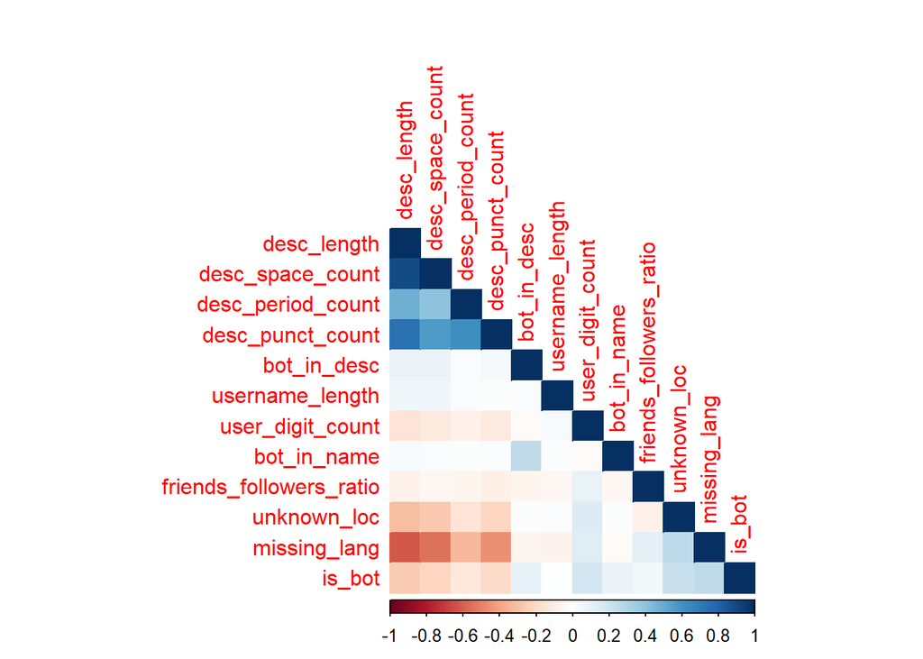

```r
correlation = cor(only_new_features)
corrplot(correlation, method = 'color', type = "lower")
```

Only several of the features are strongly correlated. Make a dataframe with only the correlated features.

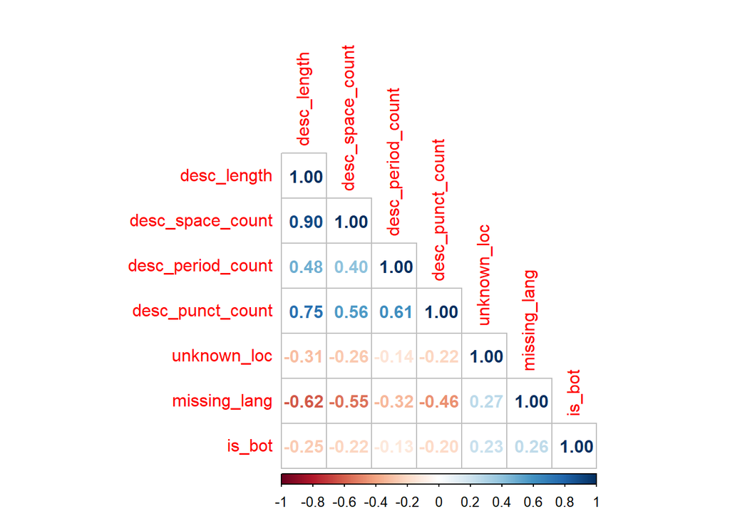

```r
cor_feature = only_new_features%>%
  select(-bot_in_desc,-username_length,-user_digit_count,-bot_in_name,-friends_followers_ratio)

correlation2 = cor(cor_feature)
corrplot(correlation2, method = 'number', type = "lower")
```

Description length and Description Space Count are most highly correlated (0.90). However, even this is below the 0.95 benchmark, so no features have to be removed.

## EDA for Remaining Engineered Features

Has Description

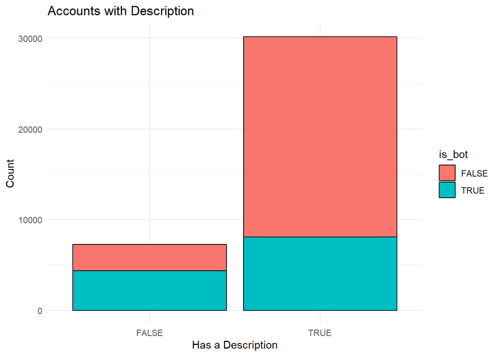

```r
ggplot(data = bots_FE, mapping = aes(x=str_length(description)!=0,fill=is_bot))+
  geom_histogram(stat="count",color = "black")+
  ggtitle("Accounts with Description")+
  xlab("Has a Description")+
  ylab("Count")+
  theme_minimal()
```

```r
has_description_model = glm(is_bot~has_desc, data = with_features, family = binomial)

summary(has_description_model)
```

```
##
## Call:
## glm(formula = is_bot ~ has_desc, family = binomial, data = with_features)
##
## Coefficients:
##              Estimate Std. Error z value Pr(>|z|)
## (Intercept)   0.40053    0.02395   16.72   <2e-16 ***
## has_descTRUE -1.40718    0.02725  -51.63   <2e-16 ***
## ---
## Signif. codes:  0 '***' 0.001 '**' 0.01 '*' 0.05 '.' 0.1 ' ' 1
##
## (Dispersion parameter for binomial family taken to be 1)
##
##     Null deviance: 47577  on 37434  degrees of freedom
## Residual deviance: 44835  on 37433  degrees of freedom
## AIC: 44839
##
## Number of Fisher Scoring iterations: 4
```

Description length

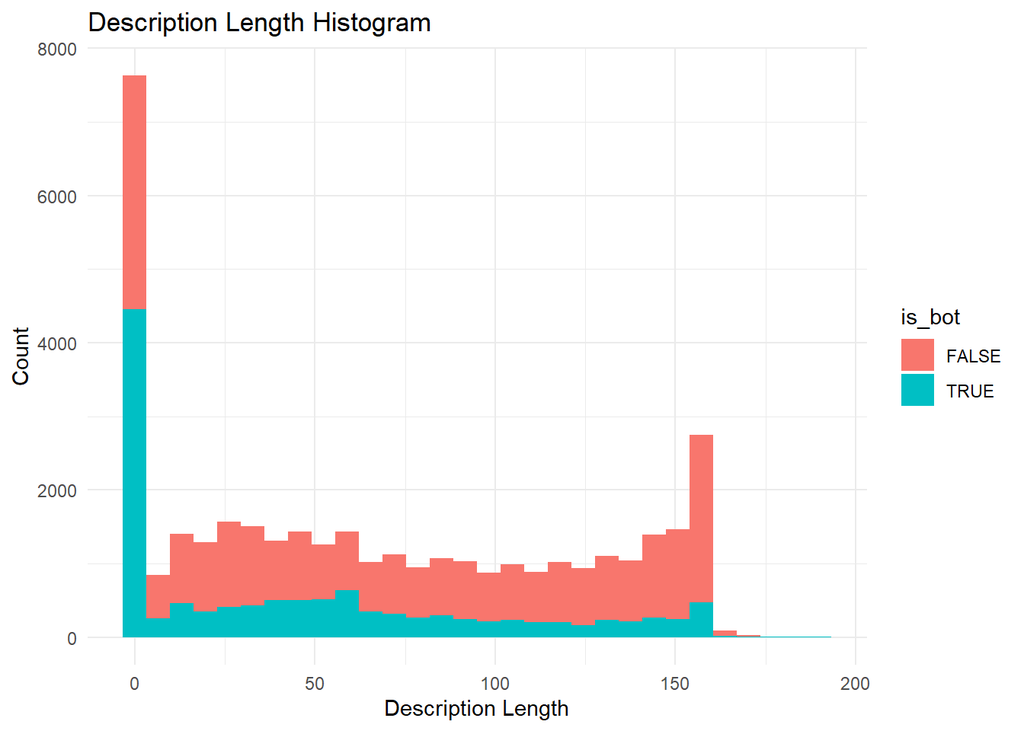

```r
ggplot(data = bots_FE, mapping = aes(x=str_length(description),fill=is_bot))+
  geom_histogram()+
  ggtitle("Description Length Histogram")+
  xlab("Description Length")+
  ylab("Count")+
  theme_minimal()
```

```r
model = glm(is_bot~str_length(description),data=bots_FE,family = binomial)
summary(model)
```

```
##
## Call:
## glm(formula = is_bot ~ str_length(description), family = binomial,
##     data = bots_FE)
##
## Coefficients:
##                           Estimate Std. Error z value Pr(>|z|)
## (Intercept)             -0.0508961  0.0167071  -3.046  0.00232 **
## str_length(description) -0.0105952  0.0002207 -48.010  < 2e-16 ***
## ---
## Signif. codes:  0 '***' 0.001 '**' 0.01 '*' 0.05 '.' 0.1 ' ' 1
##
## (Dispersion parameter for binomial family taken to be 1)
##
##     Null deviance: 47577  on 37434  degrees of freedom
## Residual deviance: 45047  on 37433  degrees of freedom
## AIC: 45051
##
## Number of Fisher Scoring iterations: 4
```

Number of spaces in description

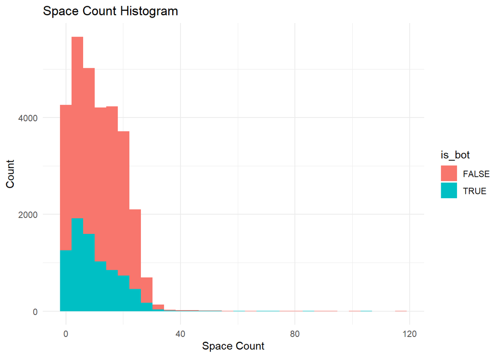

```r
ggplot(data = bots_FE%>%filter(description!=""), mapping = aes(str_count(description,"\\s"),fill=is_bot))+
  geom_histogram()+
  ggtitle("Space Count Histogram")+
  xlab("Space Count")+
  ylab("Count")+
  theme_minimal()
```

```r
model = glm(is_bot~str_count(description,"\\s"),data=bots_FE,family = binomial)
summary(model)
```

```
##
## Call:
## glm(formula = is_bot ~ str_count(description, "\\s"), family = binomial,
##     data = bots_FE)
##
## Coefficients:
##                                  Estimate Std. Error z value Pr(>|z|)
## (Intercept)                     -0.188473   0.015919  -11.84   <2e-16 ***
## str_count(description, "\\\\s") -0.059689   0.001451  -41.14   <2e-16 ***
## ---
## Signif. codes:  0 '***' 0.001 '**' 0.01 '*' 0.05 '.' 0.1 ' ' 1
##
## (Dispersion parameter for binomial family taken to be 1)
##
##     Null deviance: 47577  on 37434  degrees of freedom
## Residual deviance: 45688  on 37433  degrees of freedom
## AIC: 45692
##
## Number of Fisher Scoring iterations: 4
```

Periods in Description

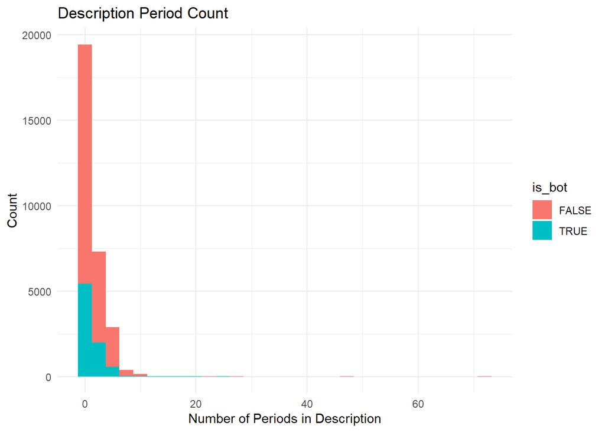

```r
ggplot(data = bots_FE%>%filter(description!=""), mapping = aes(str_count(description,"\\."),fill=is_bot))+
  geom_histogram()+
  ggtitle("Description Period Count")+
  xlab("Number of Periods in Description")+
  ylab("Count")+
  theme_minimal()
```

```r
model = glm(is_bot~str_count(description,"\\."),data=bots_FE,family = binomial)
summary(model)
```

```
##
## Call:
## glm(formula = is_bot ~ str_count(description, "\\."), family = binomial,
##     data = bots_FE)
##
## Coefficients:
##                                 Estimate Std. Error z value Pr(>|z|)
## (Intercept)                     -0.49763    0.01328  -37.48   <2e-16 ***
## str_count(description, "\\\\.") -0.19418    0.00784  -24.77   <2e-16 ***
## ---
## Signif. codes:  0 '***' 0.001 '**' 0.01 '*' 0.05 '.' 0.1 ' ' 1
##
## (Dispersion parameter for binomial family taken to be 1)
##
##     Null deviance: 47577  on 37434  degrees of freedom
## Residual deviance: 46865  on 37433  degrees of freedom
## AIC: 46869
##
## Number of Fisher Scoring iterations: 4
```

Punctuation in Description

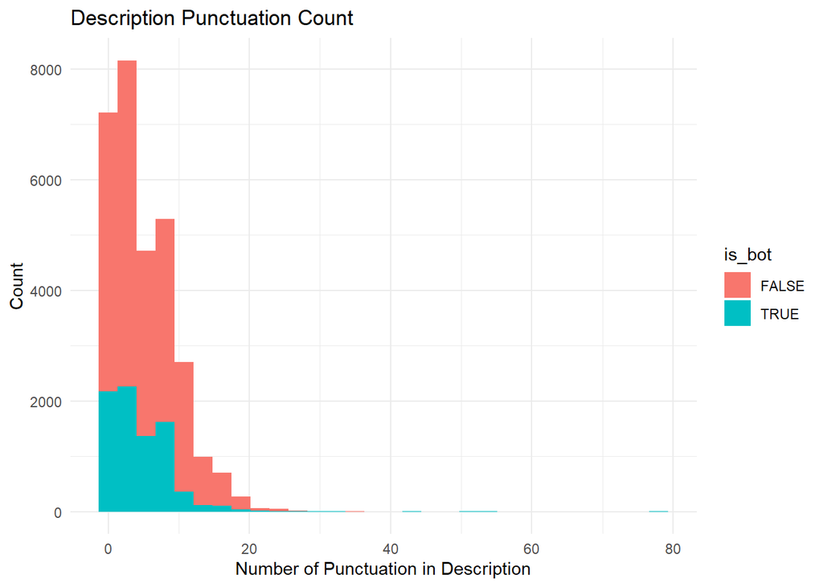

```r
ggplot(data = bots_FE%>%filter(description!=""), mapping = aes(str_count(description,"[:punct:]"), fill=is_bot))+
  geom_histogram()+
  ggtitle("Description Punctuation Count")+
  xlab("Number of Punctuation in Description")+
  ylab("Count")+
  theme_minimal()
```

```r
model = glm(is_bot~str_count(description,"[:punct:]"),data=bots_FE,family = binomial)
summary(model)
```

```
##
## Call:
## glm(formula = is_bot ~ str_count(description, "[:punct:]"), family = binomial,
##     data = bots_FE)
##
## Coefficients:
##                                      Estimate Std. Error z value Pr(>|z|)
## (Intercept)                         -0.280525   0.014966  -18.74   <2e-16 ***
## str_count(description, "[:punct:]") -0.111092   0.002949  -37.67   <2e-16 ***
## ---
## Signif. codes:  0 '***' 0.001 '**' 0.01 '*' 0.05 '.' 0.1 ' ' 1
##
## (Dispersion parameter for binomial family taken to be 1)
##
##     Null deviance: 47577  on 37434  degrees of freedom
## Residual deviance: 45937  on 37433  degrees of freedom
## AIC: 45941
##
## Number of Fisher Scoring iterations: 4
```

Bot in Description

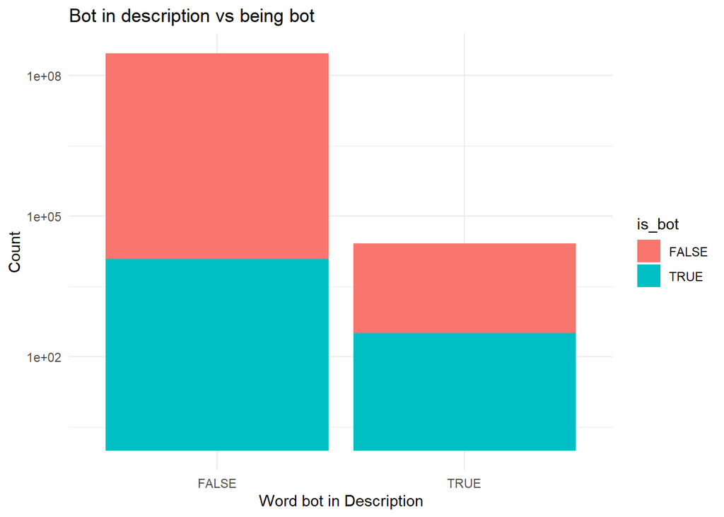

```r
ggplot(data = with_features, mapping = aes(bot_in_desc, fill=is_bot))+
  geom_bar()+
  ggtitle("Bot in description vs being bot")+
  xlab("Word bot in Description")+
  ylab("Count")+
  scale_y_log10()+
  theme_minimal()
```

```r
model = glm(is_bot~bot_in_desc,data=with_features,family = binomial)
summary(model)
```

```
##
## Call:
## glm(formula = is_bot ~ bot_in_desc, family = binomial, data = with_features)
##
## Coefficients:
##                 Estimate Std. Error z value Pr(>|z|)
## (Intercept)     -0.72303    0.01108  -65.26   <2e-16 ***
## bot_in_descTRUE  2.10623    0.12476   16.88   <2e-16 ***
## ---
## Signif. codes:  0 '***' 0.001 '**' 0.01 '*' 0.05 '.' 0.1 ' ' 1
##
## (Dispersion parameter for binomial family taken to be 1)
##
##     Null deviance: 47577  on 37434  degrees of freedom
## Residual deviance: 47200  on 37433  degrees of freedom
## AIC: 47204
##
## Number of Fisher Scoring iterations: 4
```

Username Length - not significant, to be removed

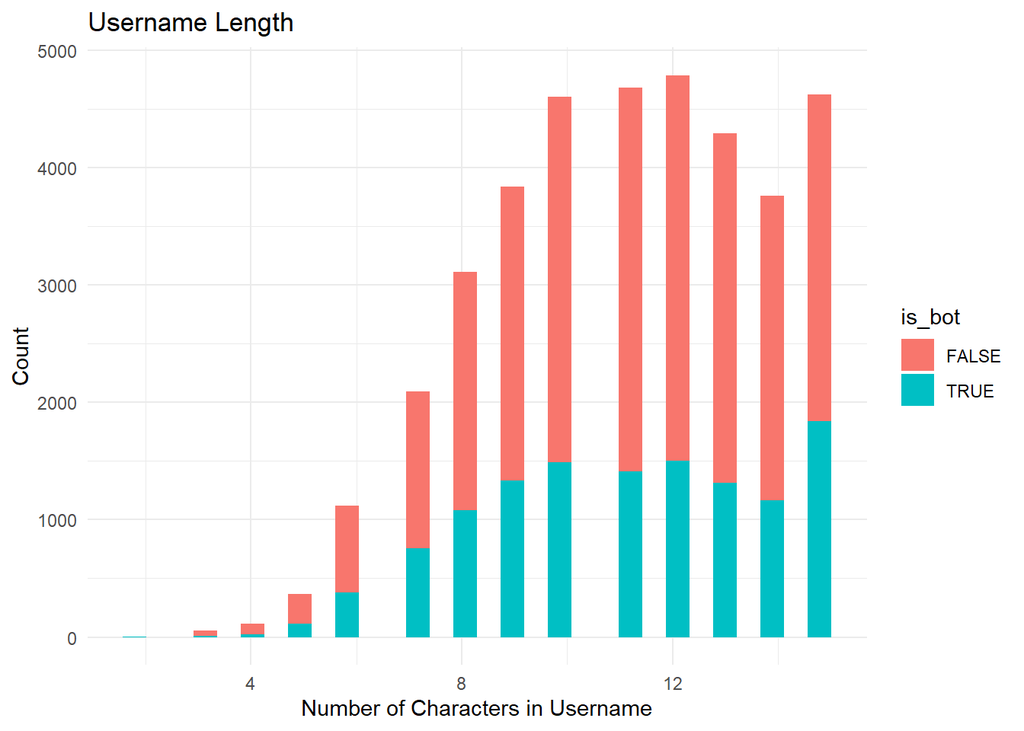

```r
ggplot(data = with_features, mapping = aes(username_length, fill=is_bot))+
  geom_histogram()+
  ggtitle("Username Length")+
  xlab("Number of Characters in Username")+
  ylab("Count")+
  theme_minimal()
```

```r
model = glm(is_bot~username_length,data=with_features,family = binomial)
summary(model)
```

```
##
## Call:
## glm(formula = is_bot ~ username_length, family = binomial, data = with_features)
##
## Coefficients:
##                  Estimate Std. Error z value Pr(>|z|)
## (Intercept)     -0.770137   0.047546 -16.198   <2e-16 ***
## username_length  0.006315   0.004158   1.519    0.129
## ---
## Signif. codes:  0 '***' 0.001 '**' 0.01 '*' 0.05 '.' 0.1 ' ' 1
##
## (Dispersion parameter for binomial family taken to be 1)
##
##     Null deviance: 47577  on 37434  degrees of freedom
## Residual deviance: 47575  on 37433  degrees of freedom
## AIC: 47579
##
## Number of Fisher Scoring iterations: 4
```

Username Digit Count

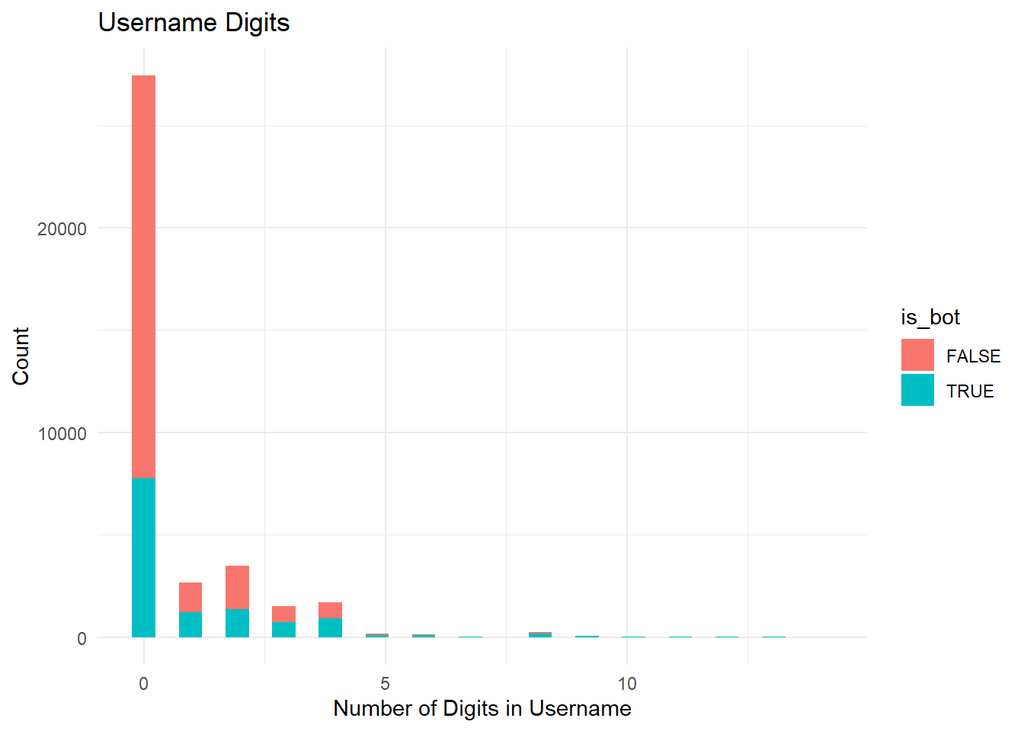

```r
ggplot(data = with_features, mapping = aes(user_digit_count, fill=is_bot))+
  geom_histogram()+
  ggtitle("Username Digits")+
  xlab("Number of Digits in Username")+
  ylab("Count")+
  theme_minimal()
```

```r
model = glm(is_bot~user_digit_count,data=with_features,family = binomial)
summary(model)
```

```
##
## Call:
## glm(formula = is_bot ~ user_digit_count, family = binomial, data = with_features)
##
## Coefficients:
##                   Estimate Std. Error z value Pr(>|z|)
## (Intercept)      -0.898045   0.012648  -71.00   <2e-16 ***
## user_digit_count  0.271515   0.008014   33.88   <2e-16 ***
## ---
## Signif. codes:  0 '***' 0.001 '**' 0.01 '*' 0.05 '.' 0.1 ' ' 1
##
## (Dispersion parameter for binomial family taken to be 1)
##
##     Null deviance: 47577  on 37434  degrees of freedom
## Residual deviance: 46339  on 37433  degrees of freedom
## AIC: 46343
##
## Number of Fisher Scoring iterations: 4
```

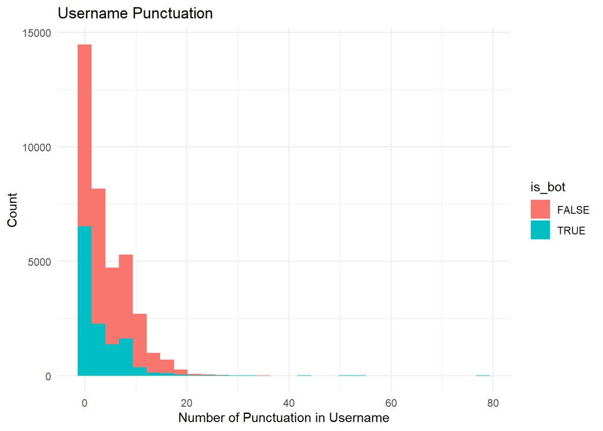

```r
ggplot(data = with_features, mapping = aes(user_punct_count, fill=is_bot))+
  geom_histogram()+
  ggtitle("Username Punctuation")+
  xlab("Number of Punctuation in Username")+
  ylab("Count")+
  theme_minimal()
```

```r
model = glm(is_bot~user_punct_count,data=with_features,family = binomial)
summary(model)
```

```
##
## Call:
## glm(formula = is_bot ~ user_punct_count, family = binomial, data = with_features)
##
## Coefficients:
##                   Estimate Std. Error z value Pr(>|z|)
## (Intercept)      -0.280525   0.014966  -18.74   <2e-16 ***
## user_punct_count -0.111092   0.002949  -37.67   <2e-16 ***
## ---
## Signif. codes:  0 '***' 0.001 '**' 0.01 '*' 0.05 '.' 0.1 ' ' 1
##
## (Dispersion parameter for binomial family taken to be 1)
##
##     Null deviance: 47577  on 37434  degrees of freedom
## Residual deviance: 45937  on 37433  degrees of freedom
## AIC: 45941
##
## Number of Fisher Scoring iterations: 4
```

Bot in Username

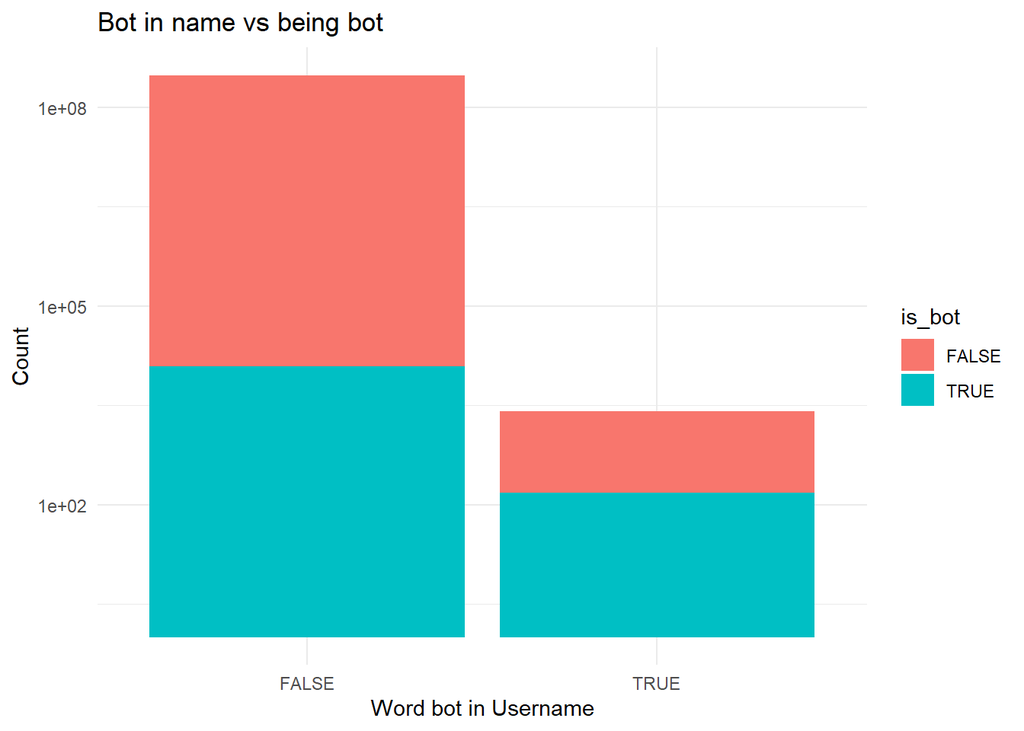

```r
ggplot(data = with_features, mapping = aes(bot_in_name, fill=is_bot))+
  geom_bar()+
  ggtitle("Bot in name vs being bot")+
  xlab("Word bot in Username")+
  ylab("Count")+
  scale_y_log10()+
  theme_minimal()
```

```r
model = glm(is_bot~bot_in_name,data=with_features,family = binomial)
summary(model)
```

```
##
## Call:
## glm(formula = is_bot ~ bot_in_name, family = binomial, data = with_features)
##
## Coefficients:
##                 Estimate Std. Error z value Pr(>|z|)
## (Intercept)     -0.71140    0.01102  -64.54   <2e-16 ***
## bot_in_nameTRUE  2.88882    0.25613   11.28   <2e-16 ***
## ---
## Signif. codes:  0 '***' 0.001 '**' 0.01 '*' 0.05 '.' 0.1 ' ' 1
##
## (Dispersion parameter for binomial family taken to be 1)
##
##     Null deviance: 47577  on 37434  degrees of freedom
## Residual deviance: 47341  on 37433  degrees of freedom
## AIC: 47345
##
## Number of Fisher Scoring iterations: 4
```

Friends to Followers Ratio

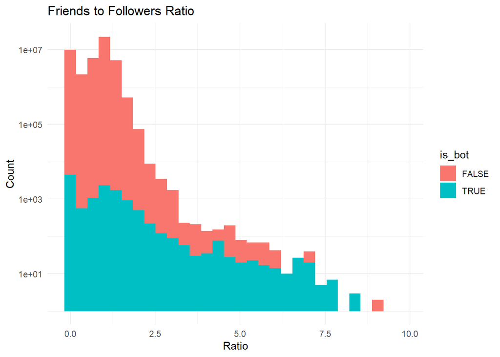

```r
ggplot(data = with_features, mapping = aes(friends_followers_ratio, fill=is_bot))+
  geom_histogram()+
  ggtitle("Friends to Followers Ratio")+
  xlab("Ratio")+
  ylab("Count")+
  scale_y_log10()+
  theme_minimal()
```

```r
model = glm(is_bot~friends_followers_ratio,data=with_features,family = binomial)
summary(model)
```

```
##
## Call:
## glm(formula = is_bot ~ friends_followers_ratio, family = binomial,
##     data = with_features)
##
## Coefficients:
##                         Estimate Std. Error z value Pr(>|z|)
## (Intercept)             -0.83753    0.01708  -49.03   <2e-16 ***
## friends_followers_ratio  0.16127    0.01516   10.64   <2e-16 ***
## ---
## Signif. codes:  0 '***' 0.001 '**' 0.01 '*' 0.05 '.' 0.1 ' ' 1
##
## (Dispersion parameter for binomial family taken to be 1)
##
##     Null deviance: 47577  on 37434  degrees of freedom
## Residual deviance: 47464  on 37433  degrees of freedom
## AIC: 47468
##
## Number of Fisher Scoring iterations: 4
```

Location Unknown

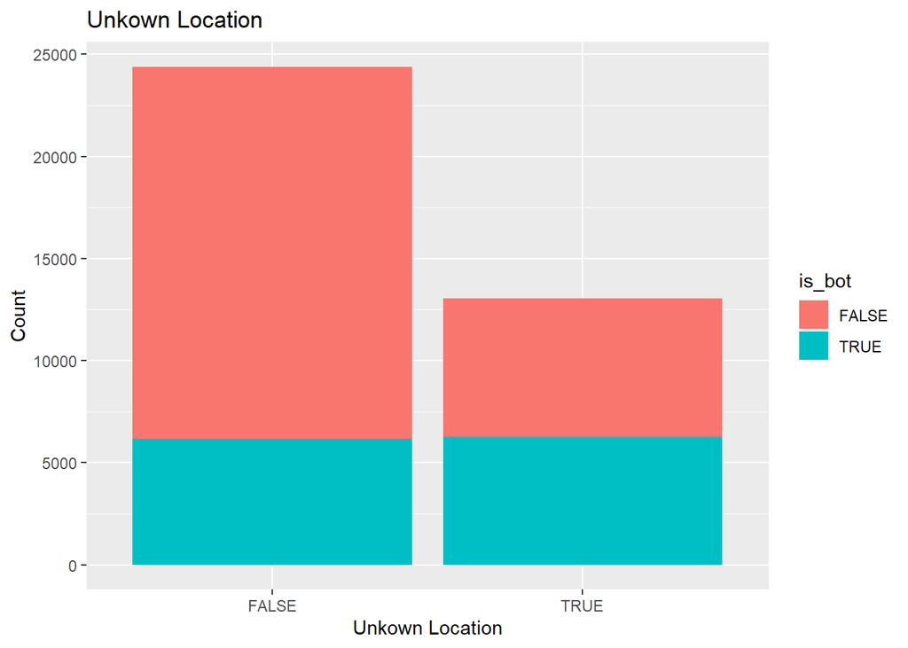

```r
ggplot(data = with_features, mapping = aes(unknown_loc, fill=is_bot))+
  geom_bar()+
  ggtitle("Unkown Location")+
  xlab("Unkown Location")+
  ylab("Count")
```

```r
  theme_minimal()
```

[output not shown]

[output cut: 333 more lines]

[output not shown]

```r
model = glm(is_bot~unknown_loc,data=with_features,family = binomial)
summary(model)
```

```
##
## Call:
## glm(formula = is_bot ~ unknown_loc, family = binomial, data = with_features)
##
## Coefficients:
##                 Estimate Std. Error z value Pr(>|z|)
## (Intercept)     -1.08434    0.01473  -73.59   <2e-16 ***
## unknown_locTRUE  1.00378    0.02290   43.84   <2e-16 ***
## ---
## Signif. codes:  0 '***' 0.001 '**' 0.01 '*' 0.05 '.' 0.1 ' ' 1
##
## (Dispersion parameter for binomial family taken to be 1)
##
##     Null deviance: 47577  on 37434  degrees of freedom
## Residual deviance: 45636  on 37433  degrees of freedom
## AIC: 45640
##
## Number of Fisher Scoring iterations: 4
```

Missing Language

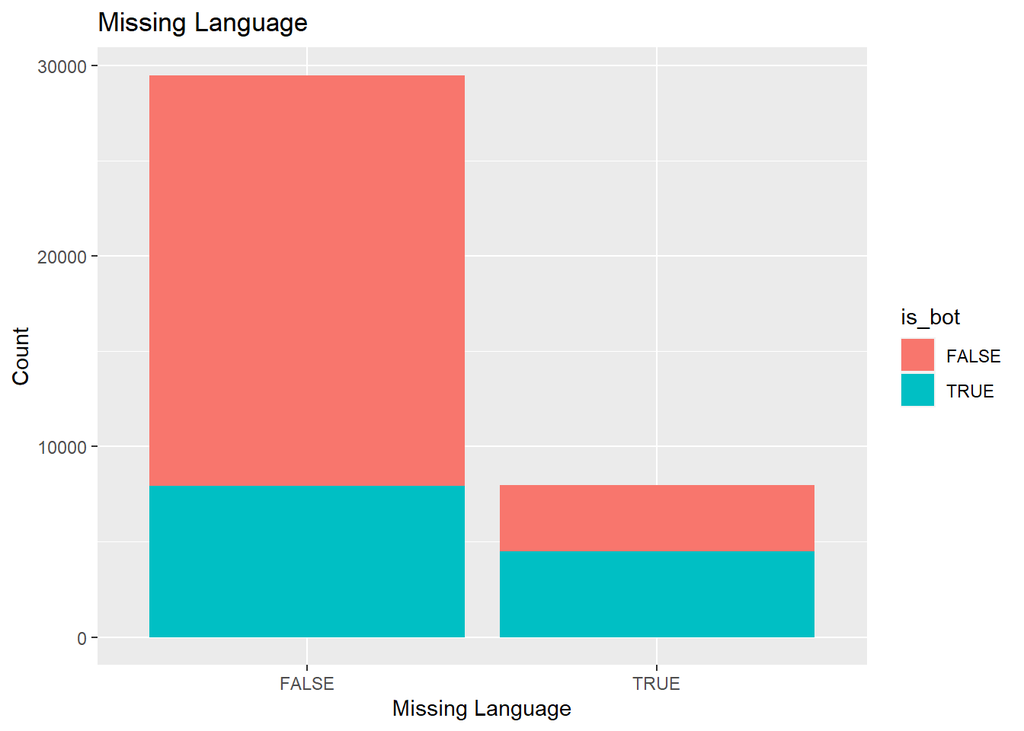

```r
ggplot(data = with_features, mapping = aes(missing_lang, fill=is_bot))+
  geom_bar()+
  ggtitle("Missing Language")+
  xlab("Missing Language")+
  ylab("Count")
```

```r
  theme_minimal()
```

[output not shown]

[output cut: 333 more lines]

[output not shown]

```r
model = glm(is_bot~missing_lang,data=with_features,family = binomial)
summary(model)
```

```
##
## Call:
## glm(formula = is_bot ~ missing_lang, family = binomial, data = with_features)
##
## Coefficients:
##                  Estimate Std. Error z value Pr(>|z|)
## (Intercept)      -0.99980    0.01313  -76.12   <2e-16 ***
## missing_langTRUE  1.25990    0.02615   48.18   <2e-16 ***
## ---
## Signif. codes:  0 '***' 0.001 '**' 0.01 '*' 0.05 '.' 0.1 ' ' 1
##
## (Dispersion parameter for binomial family taken to be 1)
##
##     Null deviance: 47577  on 37434  degrees of freedom
## Residual deviance: 45224  on 37433  degrees of freedom
## AIC: 45228
##
## Number of Fisher Scoring iterations: 4
```

Observations * Most of the engineered features are significantly correlated to the probability of the account being a bot

Impact * Username Length is not significant so it can be dropped

```r
final_df = with_features%>%
  select(-username_length)
colnames(final_df)
```

```
##  [1] "created_at"              "default_profile"
##  [3] "default_profile_image"   "description"
##  [5] "geo_enabled"             "id"
##  [7] "lang"                    "location"
##  [9] "screen_name"             "verified"
## [11] "account_age_days"        "is_bot"
## [13] "log_favourites_count"    "log_followers_count"
## [15] "log_friends_count"       "log_statuses_count"
## [17] "log_avg_tweets_per_day"  "has_desc"
## [19] "desc_length"             "desc_space_count"
## [21] "desc_period_count"       "desc_punct_count"
## [23] "bot_in_desc"             "user_digit_count"
## [25] "user_punct_count"        "bot_in_name"
## [27] "friends_followers_ratio" "unknown_loc"
## [29] "missing_lang"
```

## Feature Engineering PipeLine

```r
feature_function = function(data){
  # run data cleaning function
  cleaned = data%>%
   #  remove unnecessary columns
    select(-X,-profile_image_path,-profile_background_image_path, -profile_background_image_url, -profile_image_url)%>%

     # standardize missing location  value
    mutate(
      location = if_else(str_trim(location) == "","unknown",location))%>%

    # type cast to correct class
  mutate(
    created_at = ymd_hms(created_at),
    default_profile = as.logical(default_profile),
    default_profile_image = as.logical(default_profile_image),
    geo_enabled = as.logical(geo_enabled),
    verified = as.logical(verified))%>%

     #cast and rename account_type
  mutate(
    account_type=if_else(account_type=="bot",1,0))%>%
  rename(is_bot=account_type)%>%

    # transform and winsorize outliers
    mutate(
      # log(x+1) to avoid "-inf"
      log_favourites_count = log10(favourites_count+1),
      log_followers_count = log10(followers_count+1),
      log_friends_count = log10(friends_count+1),
      log_statuses_count = log10(statuses_count+1),
      log_avg_tweets_per_day = log10(average_tweets_per_day+1)
    )%>%
    mutate(
      log_favourites_count= Winsorize(log_favourites_count),
      log_followers_count = Winsorize(log_followers_count),
      log_friends_count = Winsorize(log_friends_count),
      log_statuses_count = Winsorize(log_statuses_count),
      log_avg_tweets_per_day = Winsorize(log_avg_tweets_per_day)
    )%>%

  # remove old columns
  select(-favourites_count,-followers_count,-friends_count, -statuses_count, -average_tweets_per_day)



  final = cleaned %>%
    # apply EDA recommendations
    select(-split)%>%
    filter(account_age_days>500)%>%
    # add new features
    mutate(is_bot=as.logical(is_bot))%>%
    mutate(has_desc=str_length(description)!=0)%>%
    mutate(desc_length=str_length(description))%>%
    mutate(desc_space_count=str_count(description,"\\s"))%>%
    mutate(desc_period_count=str_count(description,"\\."))%>%
    mutate(desc_punct_count=str_count(description,"[:punct:]"))%>%
    mutate(bot_in_desc=str_detect(`description`,"bot"))%>%
    mutate(user_digit_count=str_count(screen_name,"\\d"))%>%
    mutate(user_punct_count=str_count(description,"[:punct:]"))%>%
    mutate(bot_in_name=str_detect(`screen_name`,"bot"))%>%
    mutate(friends_followers_ratio=log_friends_count/log_followers_count)%>%
    mutate(unknown_loc=str_detect(location,"unknown"))%>%
    mutate(missing_lang = lang == "")

  return(final)
}
```